# HW 01

Author

Weston Scott

## 0 - Setup

```r
if (!require("pacman"))
    install.packages("pacman")

# Use pacman::p_load to install and load CRAN packages
pacman::p_load(
      dplyr,
      ggplot2,
      ggthemes,
      glue,
      grid,
      gridExtra,
      knitr,
      lubridate,
      openintro,
      readr,
      scales
)

# Handle GitHub package separately
if (!require("dsbox")) {
      # Install devtools if not present
      if (!require("devtools"))
          install.packages("devtools")
devtools::install_github("tidyverse/dsbox")
      library(dsbox)
}
```

## 1 - Road traffic accidents in Edinburgh

```r
accidents <- read_csv("data/accidents.csv")
glimpse(accidents)
```

```
Rows: 768
Columns: 31
$ id                 <chr> "2018950000002", "2018950000006", "2018950000012", …
$ easting            <dbl> 327174, 324874, 330500, 321890, 320120, 331752, 325…
$ northing           <dbl> 670941, 672457, 671750, 671640, 669330, 667988, 674…
$ longitude          <dbl> -3.167032, -3.204252, -3.114026, -3.251772, -3.2794…
$ latitude           <dbl> 55.92600, 55.93926, 55.93376, 55.93145, 55.91041, 5…
$ police_force       <dbl> 95, 95, 95, 95, 95, 95, 95, 95, 95, 95, 95, 95, 95,…
$ severity           <chr> "Slight", "Slight", "Slight", "Slight", "Slight", "…
$ vehicles           <dbl> 1, 1, 2, 3, 2, 3, 1, 1, 1, 2, 2, 1, 1, 1, 2, 1, 2, …
$ casualties         <dbl> 1, 1, 2, 1, 1, 1, 2, 1, 1, 1, 1, 1, 1, 4, 1, 1, 1, …
$ date               <chr> "31/12/2018", "30/12/2018", "03/01/2018", "01/01/20…
$ day_of_week        <chr> "Monday", "Sunday", "Wednesday", "Monday", "Thursda…
$ time               <time> 14:59:00, 12:50:00, 14:34:00, 02:25:00, 09:00:00, …
$ district           <dbl> 923, 923, 923, 923, 923, 923, 923, 923, 923, 923, 9…
```

[output cut: 18 more lines]

```r
accidents <- accidents |>
    mutate(
        time_hour = hour(hms(time)) +
                    minute(hms(time)) / 60, ## Convert to decimal hours

        day_type = case_when(day_of_week %in% c("Saturday",
                                                "Sunday") ~ "Weekend",
                             TRUE ~ "Weekday"),

    severity = factor(severity,
                      levels = c("Fatal",
                                 "Serious",
                                 "Slight"))
    ) |>

    filter(!is.na(time_hour)) ## Clean up NaNs
```

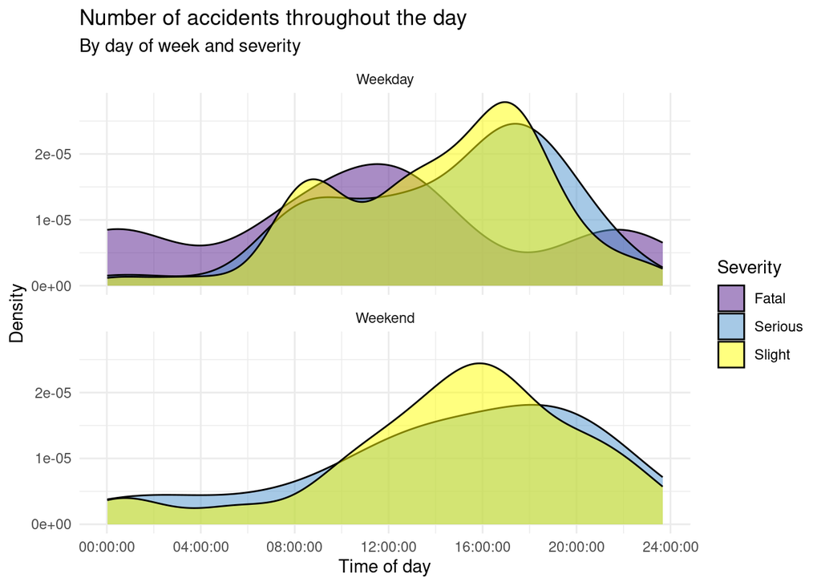

```r
ggplot(accidents,
       aes(x = time_hour * 3600,
           fill = severity)) +

    geom_density(alpha = 0.5) +
    facet_wrap(~ day_type,
               ncol = 1) +

    scale_y_continuous(labels = scientific) +
    scale_x_continuous(breaks = seq(0, 24*3600,
                                    by = 4*3600),
                       labels = sprintf("%02d:00:00",
                                        seq(0, 24, by = 4))) +

     scale_fill_manual(values = c("Fatal" = "purple4",
                                  "Serious" = "steelblue3",
                                  "Slight" = "yellow")) +

      labs(title = "Number of accidents throughout the day",
           subtitle = "By day of week and severity",
           x = "Time of day",
           y = "Density",
           fill = "Severity"
          ) +

    theme_minimal() +
    theme(legend.position = "right")
```

## 2 - NYC marathon winners

```r
marathon <- read_csv("data/nyc_marathon.csv")
glimpse(marathon)
```

```
Rows: 102
Columns: 7
$ year     <dbl> 1970, 1970, 1971, 1971, 1972, 1972, 1973, 1973, 1974, 1974, 1…
$ name     <chr> "Gary Muhrcke", NA, "Norman Higgins", "Beth Bonner", "Sheldon…
$ country  <chr> "United States", NA, "United States", "United States", "Unite…
$ time     <time> 02:31:38,       NA, 02:22:54, 02:55:22, 02:27:52, 03:08:41, …
$ time_hrs <dbl> 2.527222, NA, 2.381667, 2.922778, 2.464444, 3.144722, 2.36500…
$ division <chr> "Men", "Women", "Men", "Women", "Men", "Women", "Men", "Women…
$ note     <chr> "Course record", "No woman finishers", "Course record", "Worl…
```

```r
marathon <- marathon |>
    filter(!is.na(time_hrs))
```

### Part a

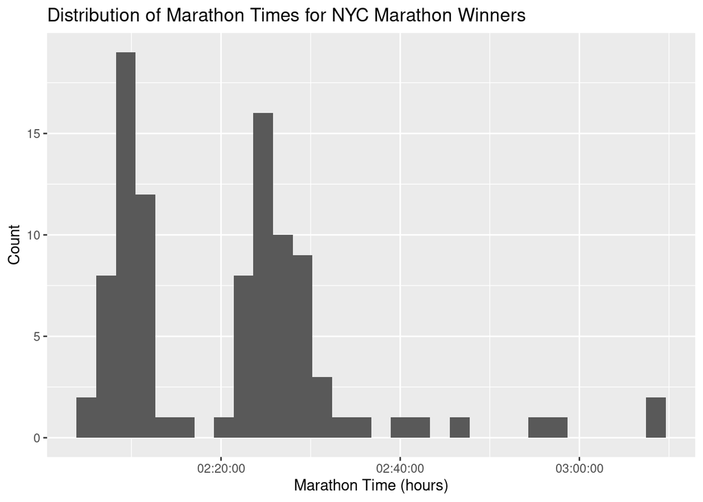

```r
ggplot(data = marathon,
       mapping = aes(x = time)) +

    geom_histogram() +
    labs(
        title = "Distribution of Marathon Times for NYC Marathon Winners",
        x = "Marathon Time (hours)",
        y = "Count"
    )
```

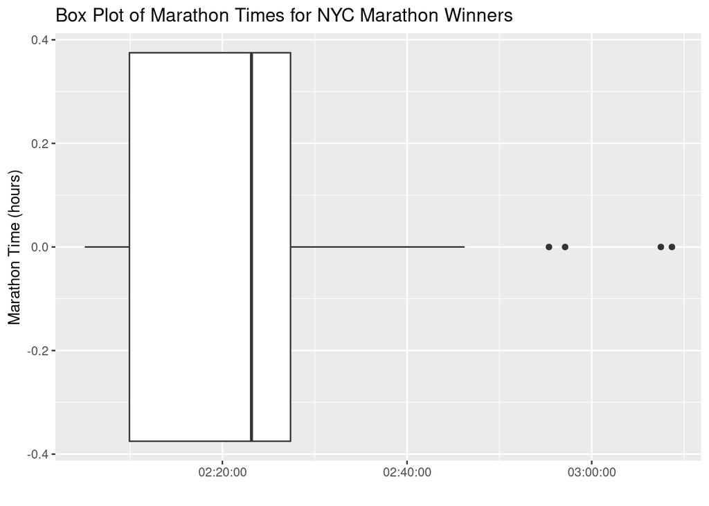

```r
ggplot(data = marathon,
       mapping = aes(x = time)) +

    geom_boxplot() +
    labs(
        title = "Box Plot of Marathon Times for NYC Marathon Winners",
        y = "Marathon Time (hours)",
        x = ""
    )
```

#### Features Apparent in Each Plot

The histogram and box plot reveal different aspects of the distribution of marathon times:

#### Features in the Histogram

The histogram shows the overall shape of the distribution (gaussian, etc.), including whether it’s unimodal or bimodal, and highlights the frequency of specific time ranges. These details about the distribution’s modality and density are not visible in the box plot.

#### Features in the Box Plot

The box plot emphasizes summary statistics, such as the median, interquartile range (IQR), and potential outliers. The quartile-based features and outliers are not explicitly shown in the histogram, which focuses on frequency rather than the statistical summaries of the data in question.

### Part b

```r
marathon <- marathon |>
    mutate(
        time_hours = as.numeric(hms(time)) / 3600
    )
```

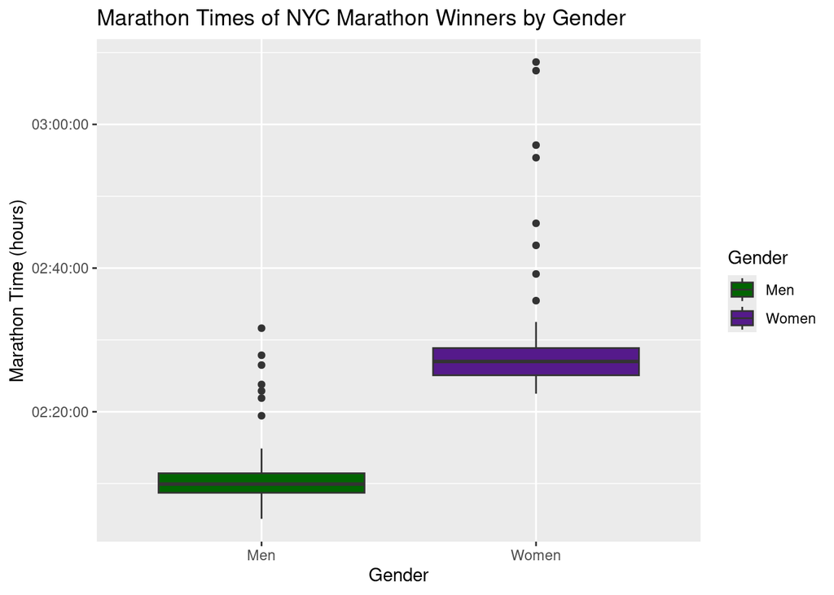

```r
ggplot(marathon,
       aes(x = division,
           y = time,
           fill = division)) +

    geom_boxplot() +
    scale_fill_manual(values = c("Men" = "darkgreen",
                               "Women" = "purple4")) +

    labs(
        title = "Marathon Times of NYC Marathon Winners by Gender",
        x = "Gender",
        y = "Marathon Time (hours)",
        fill = "Gender"
    )
```

### Part c

**Redundancy**: The plot uses both the x-axis labels “Men” and “Women”, and the legend “Gender” to convey the same information. The fill aesthetic maps to division (or gender), and the legend repeats what is already clear from the x-axis categories. Honestly, it could work even plotting the dataset as a whole and then the box-plots can be essentially inline, since they are in different regions, simply color the data by the gender as well.

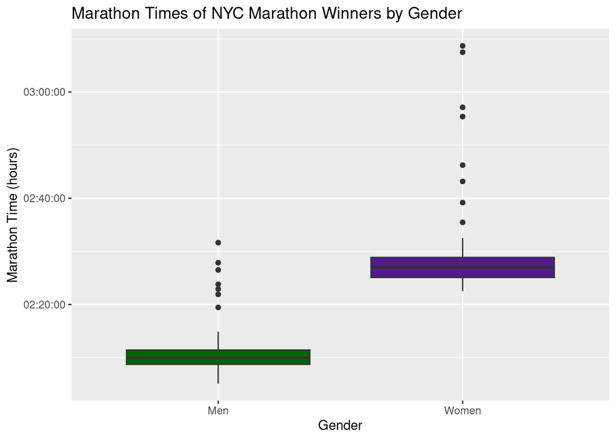

```r
ggplot(marathon,
       aes(x = division,
           y = time,
           fill = division)) +

    geom_boxplot() +
    scale_fill_manual(values = c("Men" = "darkgreen",
                               "Women" = "purple4")) +

    labs(
        title = "Marathon Times of NYC Marathon Winners by Gender",
        x = "Gender",
        y = "Marathon Time (hours)"
    ) +

    theme(legend.position = "none")
```

### Part d

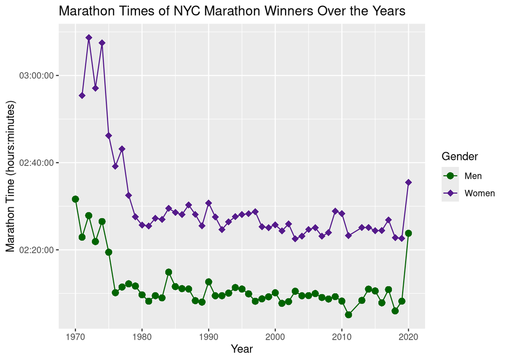

```r
ggplot(marathon,
       aes(x = year,
           y = time,
           color = division,
           shape = division)) +

    geom_point(size = 3) +
    geom_line() +
    scale_color_manual(values = c("Men" = "darkgreen",
                                  "Women" = "purple4")) +

    scale_shape_manual(values = c("Men" = 16,
                                  "Women" = 18)) +

    labs(
        title = "Marathon Times of NYC Marathon Winners Over the Years",
        x = "Year",
        y = "Marathon Time (hours:minutes)",
        color = "Gender",
        shape = "Gender"
    )
```

#### Oberservations

The trends of both the men and women lines show that post 1980, the men and women both have stabilized around their respective averages. The plot also highlights year-to-year variability and anomalies (e.g., a spike in times in a specific year (more exploratory analysis could be done). Additionally, it allows direct comparison of men’s and women’s times across years, showing that men consistently have faster times. These temporal trends and comparative dynamics are not captured in the earlier plots (histogram or boxplot).

## 3 - US counties

```r
data(county)
glimpse(county)
```

```
Rows: 3,142
Columns: 15
$ name              <chr> "Autauga County", "Baldwin County", "Barbour County"…
$ state             <fct> Alabama, Alabama, Alabama, Alabama, Alabama, Alabama…
$ pop2000           <dbl> 43671, 140415, 29038, 20826, 51024, 11714, 21399, 11…
$ pop2010           <dbl> 54571, 182265, 27457, 22915, 57322, 10914, 20947, 11…
$ pop2017           <int> 55504, 212628, 25270, 22668, 58013, 10309, 19825, 11…
$ pop_change        <dbl> 1.48, 9.19, -6.22, 0.73, 0.68, -2.28, -2.69, -1.51, …
$ poverty           <dbl> 13.7, 11.8, 27.2, 15.2, 15.6, 28.5, 24.4, 18.6, 18.8…
$ homeownership     <dbl> 77.5, 76.7, 68.0, 82.9, 82.0, 76.9, 69.0, 70.7, 71.4…
$ multi_unit        <dbl> 7.2, 22.6, 11.1, 6.6, 3.7, 9.9, 13.7, 14.3, 8.7, 4.3…
$ unemployment_rate <dbl> 3.86, 3.99, 5.90, 4.39, 4.02, 4.93, 5.49, 4.93, 4.08…
$ metro             <fct> yes, yes, no, yes, yes, no, no, yes, no, no, yes, no…
$ median_edu        <fct> some_college, some_college, hs_diploma, hs_diploma, …
$ per_capita_income <dbl> 27841.70, 27779.85, 17891.73, 20572.05, 21367.39, 15…
$ median_hh_income  <int> 55317, 52562, 33368, 43404, 47412, 29655, 36326, 436…
$ smoking_ban       <fct> none, none, partial, none, none, none, NA, NA, none,…
```

### Part a

The code attempts to create a plot using geom_point and geom_boxplot, with an intent to explore the relationship between education level and income across counties for the geom_point plots, and then compare population distributions against smoking ban categories for the boxplots. This code will not render (or work) because it defines 2 aesthetics, which cause a conflict. Also the data in question between the two plots does not share any commonality, making the plot uninterpretable.

`ggplot(county) + geom_point(aes(x = median_edu, y = median_hh_income)) + geom_boxplot(aes(x = smoking_ban, y = pop2017))`

### Part b

The second plot makes it easier to compare poverty levels across the different median education levels because it places the facet split in columns, allowing a side-by-side comparison of poverty distributions within a consistent vertical space, which is more intuitive for spotting trends or differences. Faceting variables represent comparison factors with a manageable number of items. The choice of row versus column faceting thus depends on the number of levels in the faceting variable and the need for horizontal versus vertical alignment to enhance readability and comparison ease. In this case, vertical faceting is more pleasing.

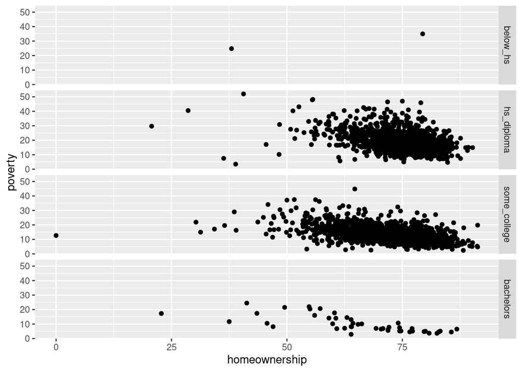

```r
ggplot(county %>% filter(!is.na(median_edu))) +
    geom_point(aes(x = homeownership, y = poverty)) +
    facet_grid(median_edu ~ .)
```

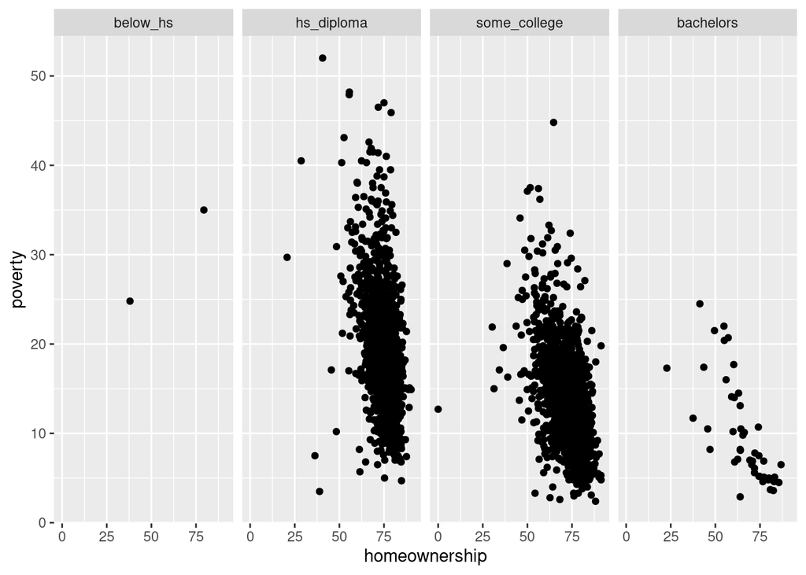

```r
ggplot(county %>% filter(!is.na(median_edu))) +
    geom_point(aes(x = homeownership, y = poverty)) +
    facet_grid(. ~ median_edu)
```

### Part c

```r
plot_a <- ggplot(county,
                 aes(x = homeownership,
                     y = poverty)) +

    geom_point() +
    labs(
        title = "Plot A"
    )
```

```r
plot_b <- ggplot(county,
                 aes(x = homeownership,
                     y = poverty)) +

    geom_point() +
    geom_smooth(se = FALSE) +
    labs(
        title = "Plot B"
    )
```

```r
plot_c <- ggplot(county,
                 aes(x = homeownership,
                     y = poverty)) +
    geom_point() +
    geom_smooth(data = subset(county,
                              metro == "yes"),
                show.legend = FALSE,
                se = FALSE,
                color = "green") +

    geom_smooth(data = subset(county,
                              metro == "no"),
                show.legend = FALSE,
                se = FALSE,
                color = "green") +

    labs(
        title = "Plot C"
    )
```

```r
plot_d <- ggplot(county,
                 aes(x = homeownership,
                     y = poverty)) +

    geom_smooth(data = subset(county,
                              metro == "yes"),
                show.legend = FALSE,
                se = FALSE,
                color = "blue") +

    geom_smooth(data = subset(county,
                              metro == "no"),
                show.legend = FALSE,
                se = FALSE,
                color = "blue") +

    geom_point() +
    labs(
        title = "Plot D"
    )
```

```r
plot_e <- ggplot(county,
                 aes(x = homeownership,
                     y = poverty,
                     color = metro)) +

    geom_point(alpha = 0.6) +
    geom_smooth(aes(linetype = metro),
                se = FALSE,
                color = "blue") +

    labs(
        title = "Plot E"
    )
```

```r
plot_f <- ggplot(county,
                 aes(x = homeownership,
                     y = poverty,
                     color = metro)) +

    geom_point(alpha = 0.6) +
    geom_smooth(se = FALSE) +
    labs(
        title = "Plot F"
    )
```

```r
plot_g <- ggplot(county,
                 aes(x = homeownership,
                     y = poverty,
                     color = metro)) +

    geom_point(alpha = 0.6) +
    geom_smooth(se = FALSE,
              color = "blue") +

    labs(
        title = "Plot G"
    )
```

```r
plot_h <- ggplot(county,
                 aes(x = homeownership,
                     y = poverty,
                     color = metro)) +

    geom_point(alpha = 0.6,
               size = 1) +

    labs(
        title = "Plot H"
    )
```

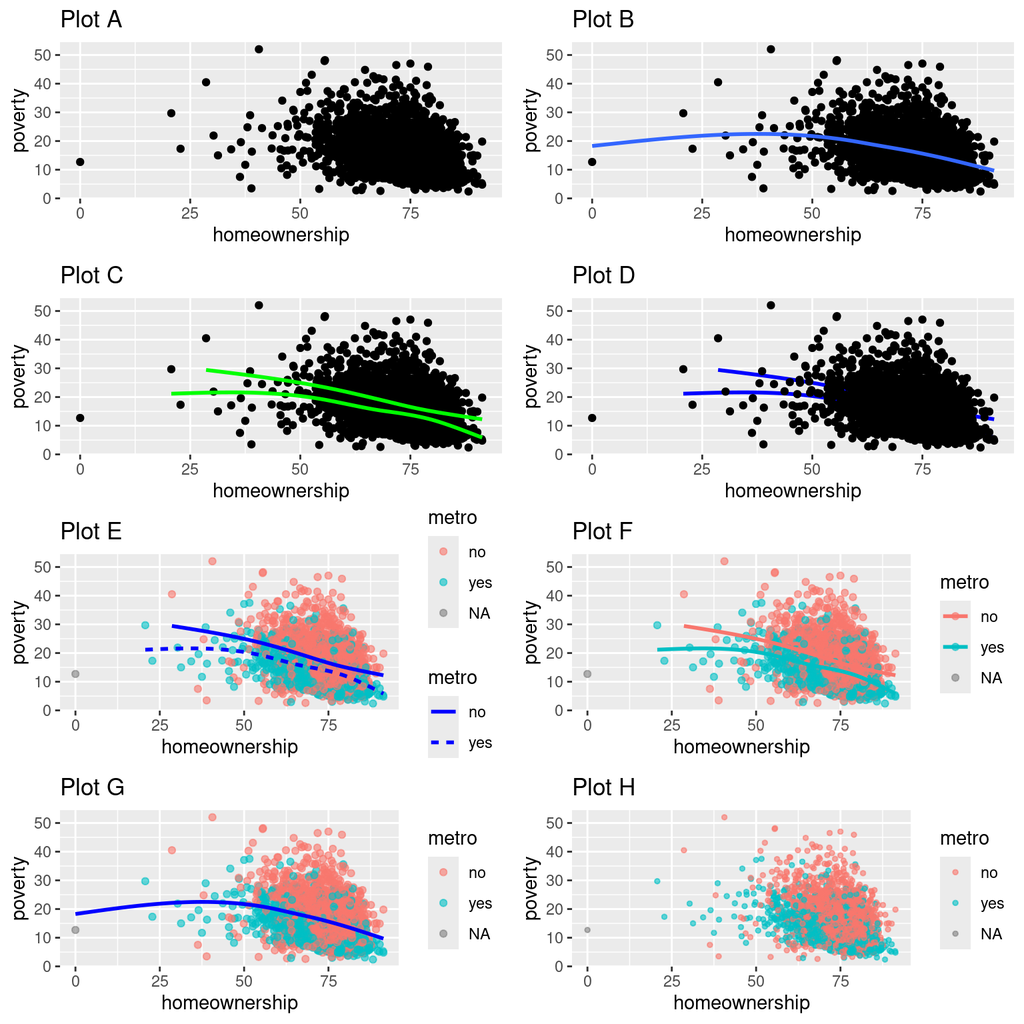

```r
grid.arrange(
    plot_a,
    plot_b,
    plot_c,
    plot_d,
    plot_e,
    plot_f,
    plot_g,
    plot_h,
    ncol = 2
)
```

Found article on how to use `gridExtra::grid.arrange()` to display multiple plots in a grid layout (STHDA 2023). Another resource helped with understanding the various parameters for the smooth function (Wickham, Chang, Henry, Pedersen, Takahashi, Wilke, Woo, Yutani, and Dunnington 2025).

```r
credit <- read_csv("data/credit.csv")
glimpse(credit)
```

```
Rows: 400
Columns: 5
$ balance <dbl> 333, 903, 580, 964, 331, 1151, 203, 872, 279, 1350, 1407, 0, 2…
$ income  <dbl> 14.891, 106.025, 104.593, 148.924, 55.882, 80.180, 20.996, 71.…
$ student <chr> "No", "Yes", "No", "No", "No", "No", "No", "No", "No", "Yes", …
$ married <chr> "Yes", "Yes", "No", "No", "Yes", "No", "No", "No", "No", "Yes"…
$ limit   <dbl> 3606, 6645, 7075, 9504, 4897, 8047, 3388, 7114, 3300, 6819, 81…
```

### Part a

```r
credit <- credit |>
    mutate(
        student = factor(student,
                         levels = c("No",
                                    "Yes")),

        married = factor(married,
                         levels = c("No",
                                    "Yes"))
    )
```

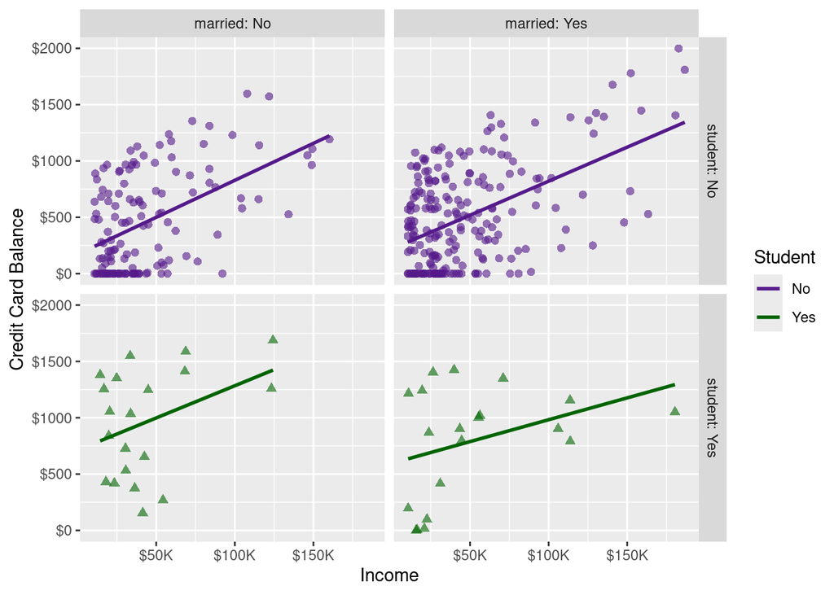

```r
ggplot(credit,
       aes(x = income,
           y = balance,
           color= student)) +

    geom_point(aes(shape = student),
               alpha = 0.6,
               size = 2,
               show.legend = FALSE) +

    geom_smooth(method = "lm",
                se = FALSE) +

    scale_y_continuous(
        breaks = seq(0, 2000, by = 500),
        labels = sprintf("$%d",
                         seq(0, 2000, by = 500))
    ) +

    scale_x_continuous(
        breaks = seq(0, 200, by = 50),
        labels = sprintf("$%dK",
                         seq(0, 200, by = 50))
    ) +

    facet_grid(student ~ married,
               labeller = label_both) +

    labs(
        x = "Income",
        y = "Credit Card Balance",
        color = "Student",
        shape = "Student"
    ) +

    scale_color_manual(values = c("No" = "purple4",
                                  "Yes" = "darkgreen")) +

    scale_shape_manual(values = c("No" = 16,
                                  "Yes" = 17))
```

### Part b

I think that the married, student, and income factors play a major role in basic pattern understanding for predicting credit-card balances. It is shown in the plots the trends corresponding to different spending quantities to balance quantities, differing between the married or student designations. A model could be made to predict this with some level of fidelity (noting that more data will improve this greatly).

### Part c

```r
credit <- credit |>
  mutate(
    credit_usage = balance / limit * 100
  )
```

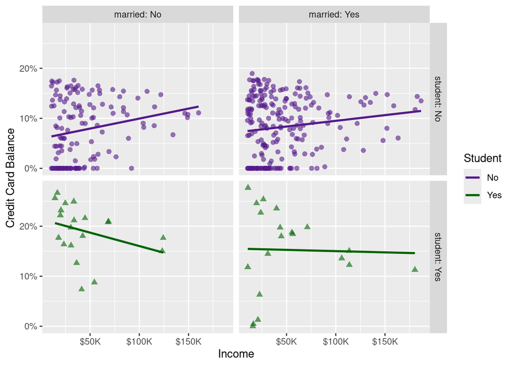

```r
ggplot(credit,
       aes(x = income,
           y = credit_usage,
           color= student)) +

    geom_point(aes(shape = student),
               alpha = 0.6,
               size = 2,
               show.legend = FALSE) +

    geom_smooth(method = "lm",
                se = FALSE) +

    scale_y_continuous(breaks = seq(0, 30,
                                    by = 10),
                       labels = sprintf("%d%%",
                                        seq(0, 30,
                                            by = 10))) +
    scale_x_continuous(breaks = seq(0, 200,
                                    by = 50),
                       labels = sprintf("$%dK",
                                        seq(0, 200,
                                            by = 50))) +

    facet_grid(student ~ married,
               labeller = label_both) +

    labs(
        x = "Income",
        y = "Credit Card Balance",
        color = "Student",
        shape = "Student"
    ) +

    scale_color_manual(values = c("No" = "purple4",
                                  "Yes" = "darkgreen")) +

    scale_shape_manual(values = c("No" = 16,
                                  "Yes" = 17))
```

## 5 - Napoleon’s march

```r
napoleon <- read_rds("data/napoleon.rds")
cities <- napoleon$cities
temperatures <- napoleon$temperatures
troops <- napoleon$troops

glimpse(cities)
```

```
Rows: 20
Columns: 3
$ long <dbl> 24.0, 25.3, 26.4, 26.8, 27.7, 27.6, 28.5, 28.7, 29.2, 30.2, 30.4,…
$ lat  <dbl> 55.0, 54.7, 54.4, 54.3, 55.2, 53.9, 54.3, 55.5, 54.4, 55.3, 54.5,…
$ city <chr> "Kowno", "Wilna", "Smorgoni", "Moiodexno", "Gloubokoe", "Minsk", …
```

```r
glimpse(temperatures)
```

```
Rows: 9
Columns: 5
$ long  <dbl> 37.6, 36.0, 33.2, 32.0, 29.2, 28.5, 27.2, 26.7, 25.3
$ temp  <dbl> 0, 0, -9, -21, -11, -20, -24, -30, -26
$ month <chr> "Oct", "Oct", "Nov", "Nov", "Nov", "Nov", "Dec", "Dec", "Dec"
$ day   <dbl> 18, 24, 9, 14, 24, 28, 1, 6, 7
$ date  <date> 1812-10-18, 1812-10-24, 1812-11-09, 1812-11-14, 1812-11-24, 1812…
```

```r
glimpse(troops)
```

```
Rows: 51
Columns: 5
$ long      <dbl> 24.0, 24.5, 25.5, 26.0, 27.0, 28.0, 28.5, 29.0, 30.0, 30.3, …
$ lat       <dbl> 54.9, 55.0, 54.5, 54.7, 54.8, 54.9, 55.0, 55.1, 55.2, 55.3, …
$ survivors <dbl> 340000, 340000, 340000, 320000, 300000, 280000, 240000, 2100…
$ direction <chr> "advancing", "advancing", "advancing", "advancing", "advanci…
$ group     <dbl> 1, 1, 1, 1, 1, 1, 1, 1, 1, 1, 1, 1, 1, 1, 1, 1, 1, 1, 1, 1, …
```

### **Recreation Steps**

#### Movement Plot

I started with making an overall ggplot object, because different dataframes will need to be overlaid and used simultaneously. The first component to add was the `geom_path` object which allowed me to map lat/long positions of troop groups, and color the lines by direction of troop movement as part of the aesthetics mapping. I was also able to change the size of the troop lines based on the survivor count, and finally add the `lineend = "round"` argument to because without it, the line segments to not appear to be continuous, resulting in poor visuals.

The next object was the `geom_point`, with which I was able to set the data to use cities in order to plot the map region with respect to where cities are located. The aesthetics mapping uses only lat and long, ensuring an overlay on top of the first part (`geom_path`). The third object was a `geom_text`, which also used the city dataframe, but is for labeling the points now. The aesthetics mapping uses only lat and long again, but also the label set to the city values. From there, I was able to adjust the vertical placement of the label with `vjust` for offsetting the label from the point.

After much time and exploring through the lecture videos more, I figured out that I could use a `geom_vline` to add a vertical component that I can add to both independent plots. I also learned that the vertical adjustment of text is like any other variable, and it can be modified at will, as I did with mutating and creating a new field based on the temperature case.

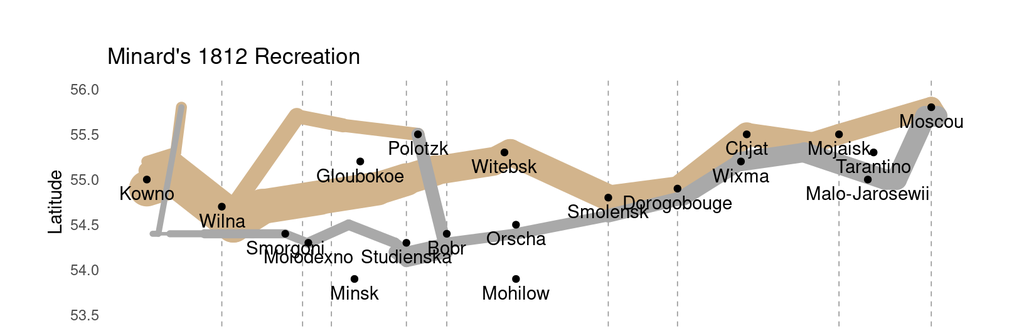

```r
movements_plot <- ggplot() +

    geom_vline(data = temperatures,
               aes(xintercept = long),
               color = "grey60",
               linetype = "dashed",
               size = 0.3) +

    geom_path(data = troops,
              aes(x = long,
                  y = lat,
                  group = group,
                  color = direction,
                  size = survivors),
              lineend = "round") +

    geom_point(data = cities,
               aes(x = long,
                   y = lat)) +

    geom_text(data = cities,
              aes(x = long,
                  y = lat,
                  label = city),
              vjust = 1.5) +

    scale_size(range = c(1, 10)) +
    scale_y_continuous(limits = c(53.5, 56)) +

    scale_colour_manual(values = c("tan", "darkgrey")) +
    labs(
        title = "Minard's 1812 Recreation",
        x = NULL,
        y = "Latitude"
    ) +

    guides(color = FALSE, size = FALSE) +
    theme_minimal() +
    theme(
        panel.grid.major = element_blank(),
        panel.grid.minor = element_blank(),
        axis.text.x = element_blank(),
        axis.ticks.x = element_blank(),
        plot.margin = margin(1, 1, 0, 1, 'cm')
    )

movements_plot
```

#### Temperatures Plot

The temperature plot uses one overall aesthetic mapping based on the temperature data, mapping longitude versus temperature. I used the `geom_path` to create the temperature similarly to the movements plot, that way I can have the lines map to a color gradient for the temperature differences as well as have the lines grow in thickness as the temperature grows. I managed to plot the temperature values along the line using the `geom_text` function again, I needed to add the date as well, to do that I would need to create multiple aesthetic mappings as was done in the movements plot in order to utilize multiple dataframes. I adjusted the top margin on this plot to stitch below the movement plot. I thought that adding a secondary axis label (top of temperature plot) was appropriate for displaying the dates that in the original plot are merged with the temperature labels along the temperature. I felt that this made the plot look a little cleaner and more organized. Ggplot truly is so customizable, that if you have a random idea, it is probably doable (just like the this second axis labeling).

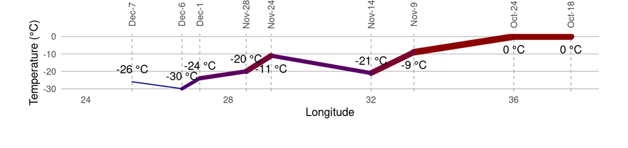

```r
temperatures <- temperatures |>
    mutate(
        temp_labels = glue("{temp} °C"),
        month_day = glue("{month}-{day}"),
        label_vjust = case_when(
          temp <= -15 ~ -1.0,
          TRUE ~ 2.0
        )
    )

temps_plot <- ggplot(data = temperatures,
                     aes(x = long,
                         y = temp)) +

    geom_vline(aes(xintercept = long),
               color = "grey60",
               linetype = "dashed",
               size = 0.3) +

    geom_path(aes(color = temp,
                  size = temp),
              lineend = "round") +

    geom_text(aes(label = temp_labels,
              vjust = label_vjust)) +

    scale_color_gradient(low = "darkblue",
                         high = "darkred",
                         guide = "none") +

    scale_size(range = c(0.5, 3),
               guide = "none") +

    scale_x_continuous(
        name = "Longitude",
        sec.axis = sec_axis(
            trans = ~.,
            breaks = temperatures$long,
            labels = temperatures$month_day
        ),
        limits = c(min(troops$long),
                   max(troops$long))
    ) +

    labs(y = "Temperature (°C)") +

    theme_minimal() +
    theme(
        plot.margin = margin(0, 1, 1, 1, 'cm'),
        axis.ticks.x = element_blank(),
        axis.text.x.top = element_text(angle = 90,
                                       vjust = 0.5),
        panel.grid.major.y = element_line(color = "grey80"),
        panel.grid.major.x = element_blank(),
        panel.grid.minor = element_blank()
    )

temps_plot
```

#### Combination Plot

Combining the two plots was seamless after adjusting the margins (which took a bit of time to figure out). However, I had to scale the movement plot to take more height that the temperature plot, then ultimately add a border around the plot. Found help on merging plots and making borders (Wickham, Chang, Henry, Pedersen, Takahashi, Wilke, Woo, Yutani, Dunnington, and Brand 2025), (Auguie and Antonov 2025), (R Core Team 2025).

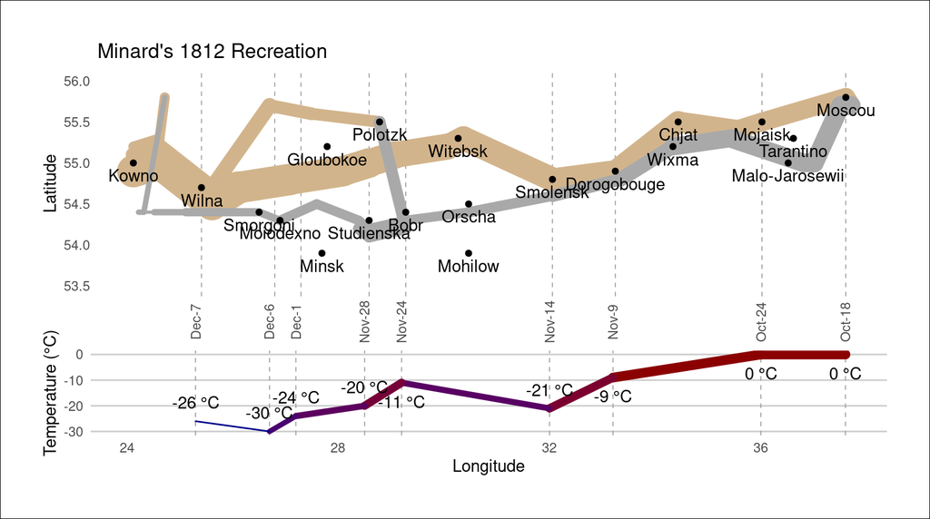

```r
combo_plot <- grid.arrange(
    movements_plot,
    temps_plot,
    ncol = 1,
    heights = c(1.375, 1)
)

grid.newpage()
grid.draw(combo_plot)
grid.rect(
    x = unit(0.5, "npc"),
    y = unit(0.5, "npc"),
    width = unit(1, "npc"),
    height = unit(1, "npc"),
    gp = gpar(
        col = "black",
        fill = NA,
        lwd = 1
    )
)
```

## References

Auguie, Baptiste, and Anton Antonov. 2025. *gridExtra: Miscellaneous Functions for "Grid" Graphics*. https://CRAN.R-project.org/package=gridExtra.

Heiss, Andrew. 2017. “Exploring Minard’s 1812 Plot with Ggplot2.” andrewheiss.com; https://www.andrewheiss.com/blog/2017/08/10/exploring-minards-1812-plot-with-ggplot2/.

R Core Team. 2025. *R: A Language and Environment for Statistical Computing*. Vienna, Austria: R Foundation for Statistical Computing. https://www.R-project.org/.

STHDA. 2023. “Ggplot2 Scatter Plots.” https://www.sthda.com/english/wiki/wiki.php?id_contents=7930.

Wickham, Hadley, Winston Chang, Lionel Henry, Thomas Lin Pedersen, Kohske Takahashi, Claus Wilke, Kara Woo, Hiroaki Yutani, and Dewey Dunnington. 2025. “geom_smooth: Smoothed Conditional Means.” Tidyverse; https://ggplot2.tidyverse.org/reference/geom_smooth.html.

Wickham, Hadley, Winston Chang, Lionel Henry, Thomas Lin Pedersen, Kohske Takahashi, Claus Wilke, Kara Woo, Hiroaki Yutani, Dewey Dunnington, and Teun van den Brand. 2025. *Ggplot2: Create Elegant Data Visualisations Using the Grammar of Graphics*. https://CRAN.R-project.org/package=ggplot2.